# DataScience Specialization Capstone: Exporatory analysis of the text data

Daria Stepanyan

## Executive summary

This milestone report is based on exploratory data analysis of the [SwifKey data](https://d396qusza40orc.cloudfront.net/dsscapstone/dataset/Coursera-SwiftKey.zip) provided in the context of the Coursera Data Science Capstone. The goal of this report is to load and explore three datasets containing text samples from US twitter, news and blogs in order to prepare for choosing an appropriate model for word prediction as part of the Capstone project for DataScience specialization on Coursera.

This milestone report describes the major features of the training data based on exploratory data analysis and summarizes the plans for creating the predictive model.

## Disclaimer

Some of the code was obscured for clarity, including writing and reading files to/from the disc and memory clearing. Full code can be found on [GitHub](https://github.com/lenin-grib/capstone-project).

## Loading data

```r
if (!file.exists("Coursera-SwiftKey.zip")) {
  download.file("https://d396qusza40orc.cloudfront.net/dsscapstone/dataset/Coursera-SwiftKey.zip")
  unzip("Coursera-SwiftKey.zip")
}
```

## Reading the data

The data includes text samples taken from twitter, blogs and news in 4 languages: US English, German, Russian and Finnish. For the purpose of this analysis we are using only English texts.

```r
filesen <- c("./final/en_US/en_US.twitter.txt",
        "./final/en_US/en_US.news.txt",
        "./final/en_US/en_US.blogs.txt")


full <- list()
for (i in 1:3){
        con <- file(filesen[i], "r")
        full[[i]] <- readLines(con, encoding = "UTF-8", skipNul = TRUE)
        close(con)
}
```

Examining the basic features of the data:

```r
library(stringi)

fullsum <- data.frame("File Name" = c("twitter", "news", "blogs"),
        "num.lines" = c(0,0,0),
        "total.num.words" = c(0,0,0),
        "mean.num.words"=c(0,0,0))

for (i in 1:3) {
        fullsum[i,2] <- stri_stats_general(full[[i]])[1]
        fullsum[i,3] <- sum(stri_count_words(full[[i]]))
        fullsum[i,4] <- mean(stri_count_words(full[[i]]))
}

fullsum
```

```
##   File.Name num.lines total.num.words mean.num.words
## 1   twitter   2360148        30093413       12.75065
## 2      news     77259         2674536       34.61779
## 3     blogs    899288        37546239       41.75107
```

### Sampling the data

The dataset is quite large, and would be hard to manipulate, so instead a sample proportionate to each source’s size (1%) will be taken to examine the data further

```r
library(dplyr)

take_sample <- function(list, prob) {

        set.seed(23072019)
        sam.list <- list()
        for (i in 1:3){
        sam <- as.logical (rbinom (n = fullsum[i,2],
                1, prob = prob))
        sam.list[[i]] <- data.frame(data = full[[i]][sam])
        }
        result <- rbind(sam.list[[1]],sam.list[[2]],sam.list[[3]])
}

cs_sample <- take_sample(full, 0.01)
cs_sample <- cs_sample %>% mutate(data = as.character(data))

str(cs_sample)
```

```
## 'data.frame':    33275 obs. of  1 variable:
##  $ data: chr  "Looking for a new band to blog for the month. anyone interested?" "Don't care what others think of you, and you will save yourself a lot of mental energy that instead can be used"| __truncated__ "Tables are all sold out for the Mystique Masquerade Ball." "Hey Nate! Thanks for dropp…
```

## Cleaning the data

Before proceeding with NGrams analysis cleaning of data is required as it contains a lot of unusable features such as URLs, punctuation, mentions, hashtags and so on. Since the end purpose of the project is to try and predict the words the real users want to type given some text provided by them, the absence of stemming and stripping the stopwords is deliberate. However, profanity still needs to be filtered. Initial cleaning is performed using this library: https://github.com/RobertJGabriel/Google-profanity-words which is based on the Google “bad words” list.

```r
library(tm)

corpus <- VCorpus(VectorSource(as.vector(cs_sample$data)))

# remove URLS, mentions and hashtags
toSpace <- content_transformer(function(x, pattern) gsub(pattern, " ", x))
corpus <- tm_map(corpus, toSpace, "(f|ht)tp(s?)://(.*)[.][a-z]+")
corpus <- tm_map(corpus, toSpace, "[@#][^\\s]+")

# remove numbers
corpus <- tm_map(corpus, content_transformer(removeNumbers))

# remove punctuation
corpus <- tm_map(corpus, content_transformer(removePunctuation),
        preserve_intra_word_dashes=FALSE,
        preserve_intra_word_contractions = TRUE)
# lower case
corpus <- tm_map(corpus, content_transformer(tolower))

# remove profanity:
profanityWords = readLines('profanity_list.txt')
corpus <- tm_map(corpus,removeWords, profanityWords)

# remove white spaces
corpus <- tm_map(corpus, stripWhitespace)
```

## Exploratory analysis

In this exploratory analysis the focus will be on the NGrams to try and see which words are commonly met together in the sample text. Before proceeding to analyzing NGrams, the very sparse terms will be removed for saving the memory.

```r
library(RWeka)

Unigram <- function(x) NGramTokenizer(x, Weka_control(min = 1, max = 1))
Bigram <- function(x) NGramTokenizer(x, Weka_control(min = 2, max = 2))
Trigram <- function(x) NGramTokenizer(x, Weka_control(min = 3, max = 3))
Quadgram <- function(x) NGramTokenizer(x, Weka_control(min = 4, max = 4))

ngr1 <- removeSparseTerms(TermDocumentMatrix(corpus,
        control = list(tokenize = Unigram)),0.9999)
ngr2 <- removeSparseTerms(TermDocumentMatrix(corpus,
        control = list(tokenize = Bigram)), 0.99)
ngr3 <- removeSparseTerms(TermDocumentMatrix(corpus,
        control = list(tokenize = Trigram)), 0.9999)
ngr4 <- removeSparseTerms(TermDocumentMatrix(corpus,
        control = list(tokenize = Quadgram)), 0.9999)
```

Now, to see the most popular combinations we’ll plot the results in order of decreasing frequency.

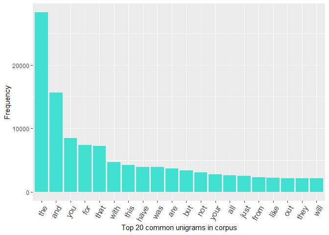

```r
library(ggplot2)

makeDF <- function(tdm) {
        total <- sort(rowSums(as.matrix(tdm)), decreasing = TRUE)
        return(data.frame(word = names(total), freq = total))
}

unidf <- makeDF(ngr1)
bidf<- makeDF(ngr2)
tridf <- makeDF(ngr3)
quaddf<- makeDF(ngr4)

plotGram <- function(df, label, top) {
        ggplot(df[1:top,], aes(reorder(word, -freq), freq)) +
                labs(x = label, y = "Frequency") +
                theme(axis.text.x = element_text(angle = 60, size = 12, hjust = 1)) +
                geom_bar(stat = "identity", fill = I("turquoise"))
}

plotGram(unidf, "Top 20 common unigrams in corpus", 20)
```

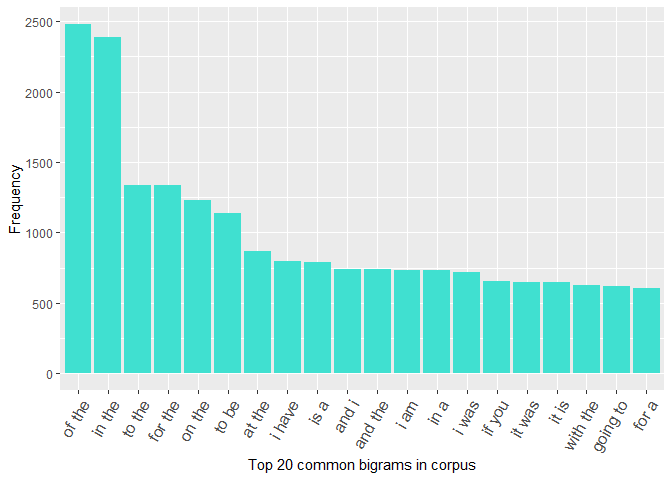

```r
plotGram(bidf, "Top 20 common bigrams in corpus", 20)
```

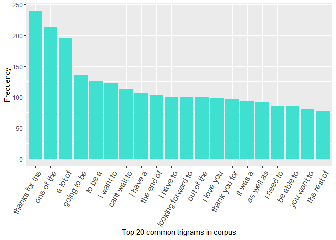

```r
plotGram(tridf, "Top 20 common trigrams in corpus", 20)
```

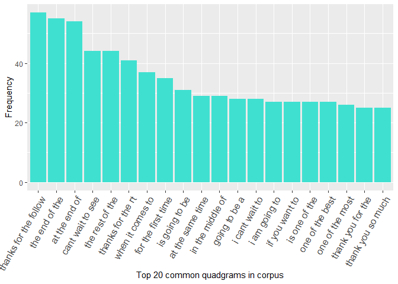

```r
plotGram(quaddf, "Top 20 common quadgrams in corpus", 20)
```

## Words coverage

**How many unique words do you need in a frequency sorted dictionary to cover 50% of all word instances in the language? 90%?**

```r
cs_sample <- read.csv("sample_en.csv")

unidf <- unidf %>% arrange(-freq)

check_coverage <- function(percentage){
coverage <- 0
total <- sum(stri_count_words(cs_sample$data))
for(i in 1:nrow(unidf)) {
        coverage <- coverage + unidf$freq[i]
        if(coverage >= percentage*total)
                {break}
}
print(i)
}

check_coverage(0.5)
```

```
## [1] 973
```

```r
check_coverage(0.9)
```

```
## [1] 10172
```

## Foreign words

**How do you evaluate how many of the words come from foreign languages?**

Generally, we can evaluate it using an english dictionary, however that would also filter out some of the recently trending words and foreign words that are used commonly by english speakers. Besides, foreign words don’t seem to be a huge problem compared to misspellings and typos, which will have to be dealt with anyway.

## Increasing the coverage

**Can you think of a way to increase the coverage – identifying words that may not be in the corpora or using a smaller number of words in the dictionary to cover the same number of phrases?**

1. We should try and correct misspelled words using one of the open libraries.
2. The common technique for smoothing the probabilities in the prediction model is to assign count of 1 to unseen n-grams, which means that all n-grams with count <2 could be dropped.
3. If we are going to use n-grams for prediction model with the backoff approach, that means that all unigrams don’t really have to be stored: only the most likely ones will ever be suggested, so we can only store top N unigrams.

### Next steps and plans on building the model

1. split dataset into train, validation and test sets.
2. clean the datasets, including profanity, misspelled or niche words (we can use news corpora to remove the words in other datasets that aren’t seen there).
3. Create N-grams up to N=4 and find an efficient way to store them.
4. Create a separate unigram table for words most used in a beginning of a line.
5. implement backoff mechanism for finding the word most likely to appear after given phrase and tune the parameters using the validation set.